# Using Random Forest Method to Predict Quality of Weight Lifting Exercise

**Data Loading & Cleaning**

Raw data are read from pml-training.csv file, and all records with the column of new_window=“yes” are discarded since the data in pml-testing.csv file don’t contain any records with the column of new_windows =“yes”. The first 7 Columns are unrelated to this study, so they are also removed.

```r
    library(caret)
    library(randomForest)
    library(gbm)
    library(RANN)
    rawData<-read.csv("pml-training.csv",na.strings = c("NA","#DIV/0!",""))
    rawData<-rawData[rawData$new_window == "no",]
    cleanData<-rawData[,-(1:7)]
```

**Data Spliting**

After cleanning, data set is randomly split into trianing and testing data sets. Outcomes in classe column are moved to a vector respectively.

```r
    set.seed(123)
    train_index <- createDataPartition(cleanData$classe, p = 0.7)[[1]]
    trainData<- cleanData[train_index,]
    testData <- cleanData[-train_index,]
    trainData_classe<-trainData$classe
    trainData$classe<-NULL
    testData_classe<-testData$classe
    testData$classe<-NULL
```

**Data Preprocessing**

Predictors with near-zero variance are filtered. The remaining predictors are firstly centered and scaled, and then transformed using BoxCox method to resolve skewness. 5-nearest neighbor method is used to impute missing data and Principal Component Analysis is conducted for feature extration.

```r
    zeroPredictor<-nearZeroVar(trainData)
    filteredTrainData<-trainData[,-zeroPredictor]
    filteredTestData<-testData[,-zeroPredictor]

    preprocessModel <- preProcess(filteredTrainData,
                                  method = c("BoxCox","center", "scale", "knnImpute", "pca"),
                                  thresh = 0.95, k = 5)
    processedTrainData <- predict(preprocessModel, filteredTrainData)
    processedTestData<- predict(preprocessModel, filteredTestData)
```

**Model Training**

The prediction model is trained on preprocessed training data set by Random Forest method with repeated 5-fold cross-validation. The tuning parameter for this model is mtry, which defines how many features are randomly selected at each split. Since there are 26 principle components remaining after preprocessing, sqrt(26)=5.1, mtry values of about half the squared-root (2), the squared-root (5),twice the squared-root (10), and full set of the principle components (26) are tested.

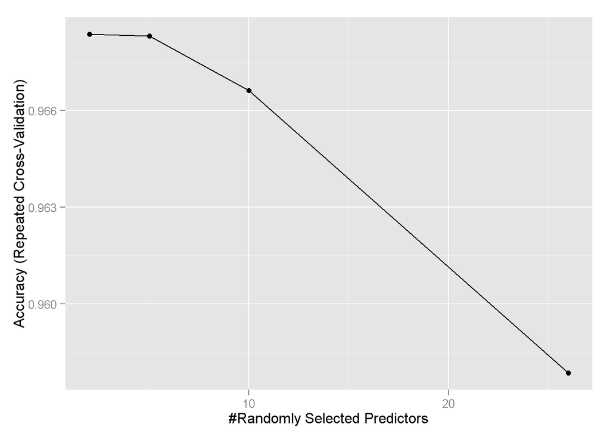

```r
    ctrl <- trainControl(method = "repeatedcv", number = 5, repeats = 5)
    grid_rf <- expand.grid(mtry = c(2,5,10,26))
    model <- train(processedTrainData, trainData_classe, method = "rf",
               trControl = ctrl, tuneGrid = grid_rf, metric = "Accuracy")
    ggplot(model)
```

**Model Testing**

```r
    testPrediction <- predict(model,processedTestData)
    confusionSummary<-confusionMatrix(testData_classe,  testPrediction )
    confusionSummary$table
```

```
##           Reference
## Prediction    A    B    C    D    E
##          A 1623    9    3    5    1
##          B   25 1072   16    0    2
##          C    2   20  974    8    1
##          D    0    3   26  915    0
##          E    1    2    3    7 1045
```

```r
    confusionSummary$overall
```

```
##       Accuracy          Kappa  AccuracyLower  AccuracyUpper   AccuracyNull
##      0.9767482      0.9705814      0.9725207      0.9804830      0.2864827
## AccuracyPValue  McnemarPValue
##      0.0000000      0.0002073
```

**Model Application**

The prediction Model is applied to the 20 records from pml-testing.csv file, the result is submit to the automatic grader.

```r
    appData<-read.csv("pml-testing.csv",na.strings = c("NA","#DIV/0!",""))
    appData<-appData[,-(1:7)]
    appData$problem_id<-NULL
    filteredAppData<-appData[,-zeroPredictor]
    processedAppData<- predict(preprocessModel, filteredAppData)
    answer <- predict(model,processedAppData)
```